# HW1 Question 3 - Machine Learning

Eduardo Schiappa Pietra Nieto

# Question 3.1

## Part A

### Adequacy of Predictors for splitting (Just an initial look before answering the question)

We see the attributes and check their distribution between the labels

```
##
##   0   1
## 286 169
```

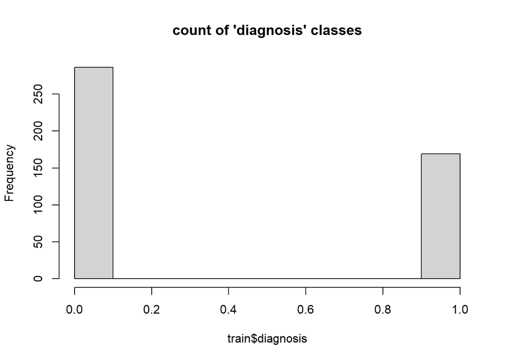

Here we show the distribution of each attribute between the two labels of the target variable. This gives us initial insight about which are the best attributes (We want those wich have a more “uneven” distribution).

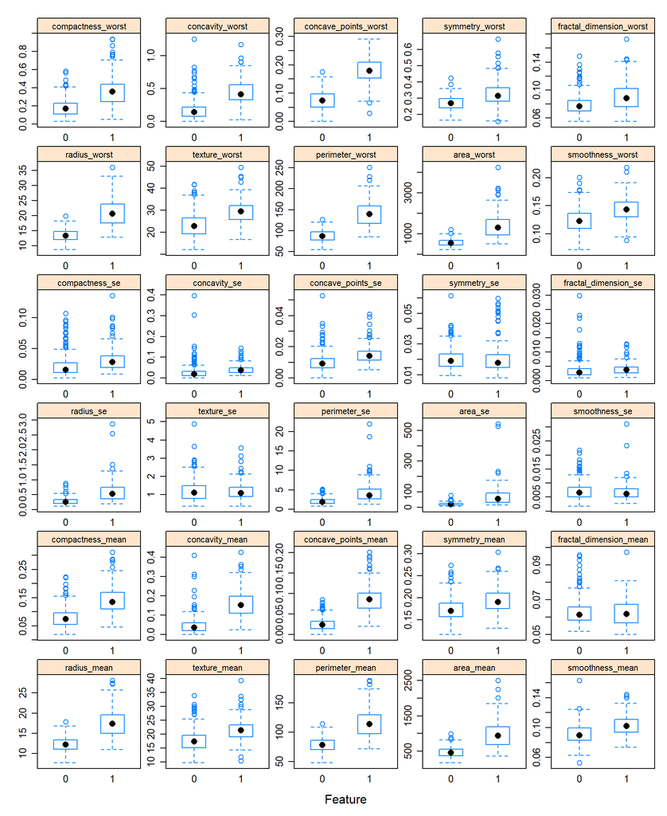

Here we are plotting in descending order the number of perfect splits for each attribute. The first attributes in the horizontal axis have more perfect splits which is good for prediction (and also for avoiding overfitting).

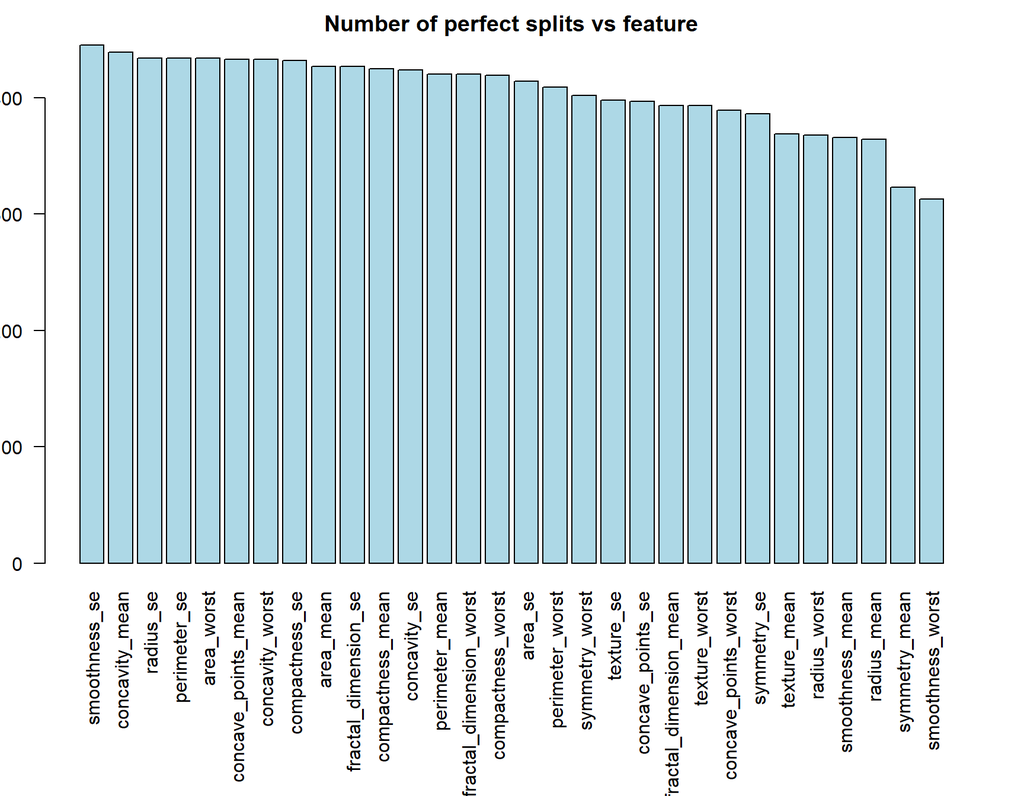

# Now we estimate the trees: ID3, C4.5 and Random Forest

## 1. ID3

This is the results of the ID3 model (We use the algorithm for CART but change the split criteria to Information Gain) ‘CP’ is the complexity parameter or ‘regularizer’ (lambda) and accuracy is the number of correct predictions over total number of prediction

```
## CART
##
## 455 samples
##  30 predictor
##   2 classes: '0', '1'
##
## No pre-processing
## Resampling: Cross-Validated (5 fold)
## Summary of sample sizes: 364, 364, 363, 364, 365
## Resampling results across tuning parameters:
##
##   cp          Accuracy   Kappa
##   0.01775148  0.9231698  0.8334257
##   0.04142012  0.9253198  0.8391521
##   0.78698225  0.7940235  0.4765430
##
## Accuracy was used to select the optimal model using the largest value.
## The final value used for the model was cp = 0.04142012.
```

Here we show a plot of the tree for ID3. Each node shows the % of observations in each label and the proportion of the total observations that falls in that node. It also shows the cutoff points for the attributes.

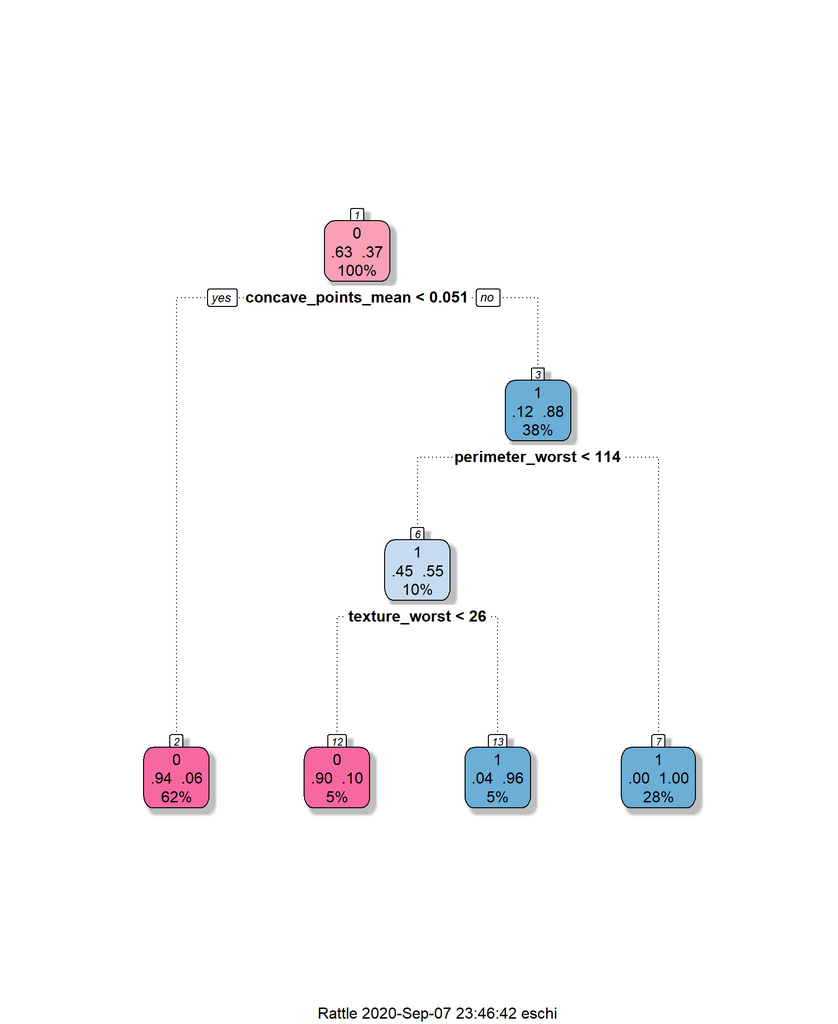

Next we show several indicators of classification such as sensitivity and specificity

```
## Confusion Matrix and Statistics
##
##           Reference
## Prediction   0   1
##          0 285  18
##          1   1 151
##
##                Accuracy : 0.9582
##                  95% CI : (0.9356, 0.9747)
##     No Information Rate : 0.6286
##     P-Value [Acc > NIR] : < 2.2e-16
##
##                   Kappa : 0.9087
##
##  Mcnemar's Test P-Value : 0.0002419
##
##             Sensitivity : 0.9965
##             Specificity : 0.8935
##          Pos Pred Value : 0.9406
##          Neg Pred Value : 0.9934
##              Prevalence : 0.6286
##          Detection Rate : 0.6264
##    Detection Prevalence : 0.6659
##       Balanced Accuracy : 0.9450
##
##        'Positive' Class : 0
##
```

Here we have the confusion matrix

```r
con_mat_id3$table
```

```
##           Reference
## Prediction   0   1
##          0 285  18
##          1   1 151
```

## 2. CART

Results of the model

```
## CART
##
## 455 samples
##  30 predictor
##   2 classes: '0', '1'
##
## No pre-processing
## Resampling: Cross-Validated (5 fold)
## Summary of sample sizes: 364, 363, 364, 364, 365
## Resampling results across tuning parameters:
##
##   cp          Accuracy   Kappa
##   0.01775148  0.9077358  0.8022381
##   0.04142012  0.8988958  0.7805790
##   0.78698225  0.8945490  0.7703152
##
## Accuracy was used to select the optimal model using the largest value.
## The final value used for the model was cp = 0.01775148.
```

Plot

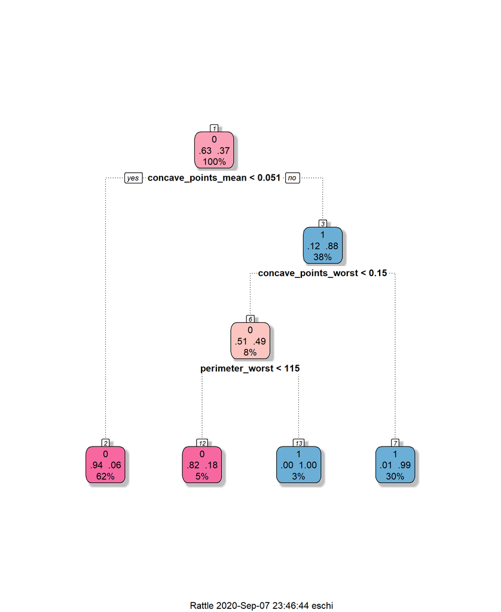

Confusion Matrix

```
##           Reference
## Prediction   0   1
##          0 284  20
##          1   2 149
```

## 3. Random Forest

Results of the model

```
## Random Forest Rule-Based Model
##
## 455 samples
##  30 predictor
##   2 classes: '0', '1'
##
## No pre-processing
## Resampling: Cross-Validated (5 fold)
## Summary of sample sizes: 364, 365, 364, 364, 363
## Resampling results across tuning parameters:
##
##   mtry  maxdepth  Accuracy   Kappa
##    2    2         0.9384589  0.8668389
##   16    3         0.9340378  0.8578237
##   30    4         0.9583124  0.9103235
##
## Accuracy was used to select the optimal model using the largest value.
## The final values used for the model were mtry = 30 and maxdepth = 4.
```

Confusion Matrix

```
##           Reference
## Prediction   0   1
##          0 284   3
##          1   2 166
```

# Question 3.1

## Part B

All this is part of the procedure we did in A.  
1. We divide the training data into 5 folds. We use 4 of them to train the model.

Here we show the results. First the indicators and then the confusion matrix

```
## Random Forest Rule-Based Model
##
## 455 samples
##  30 predictor
##   2 classes: '0', '1'
##
## No pre-processing
## Resampling: Cross-Validated (5 fold)
## Summary of sample sizes: 364, 365, 364, 364, 363
## Resampling results across tuning parameters:
##
##   mtry  maxdepth  Accuracy   Kappa
##    2    2         0.9384589  0.8668389
##   16    3         0.9340378  0.8578237
##   30    4         0.9583124  0.9103235
##
## Accuracy was used to select the optimal model using the largest value.
## The final values used for the model were mtry = 30 and maxdepth = 4.
```

```
##       Accuracy          Kappa  AccuracyLower  AccuracyUpper   AccuracyNull
##   9.890110e-01   9.764373e-01   9.745428e-01   9.964225e-01   6.285714e-01
## AccuracyPValue  McnemarPValue
##   2.081881e-82   1.000000e+00
```

```
##          Sensitivity          Specificity       Pos Pred Value
##            0.9930070            0.9822485            0.9895470
##       Neg Pred Value            Precision               Recall
##            0.9880952            0.9895470            0.9930070
##                   F1           Prevalence       Detection Rate
##            0.9912740            0.6285714            0.6241758
## Detection Prevalence    Balanced Accuracy
##            0.6307692            0.9876278
```

Confusion Matrix

```r
con_mat_rf$table
```

```
##           Reference
## Prediction   0   1
##          0 284   3
##          1   2 166
```

# Question 3.1

## Part C

We plot the ROC curves for each feature (one by one and then all of them in one graph)

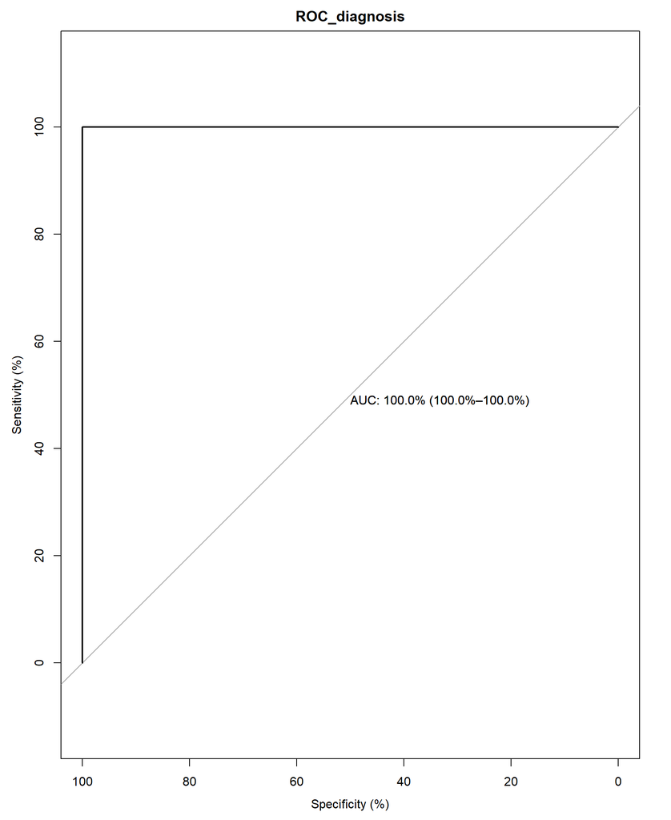

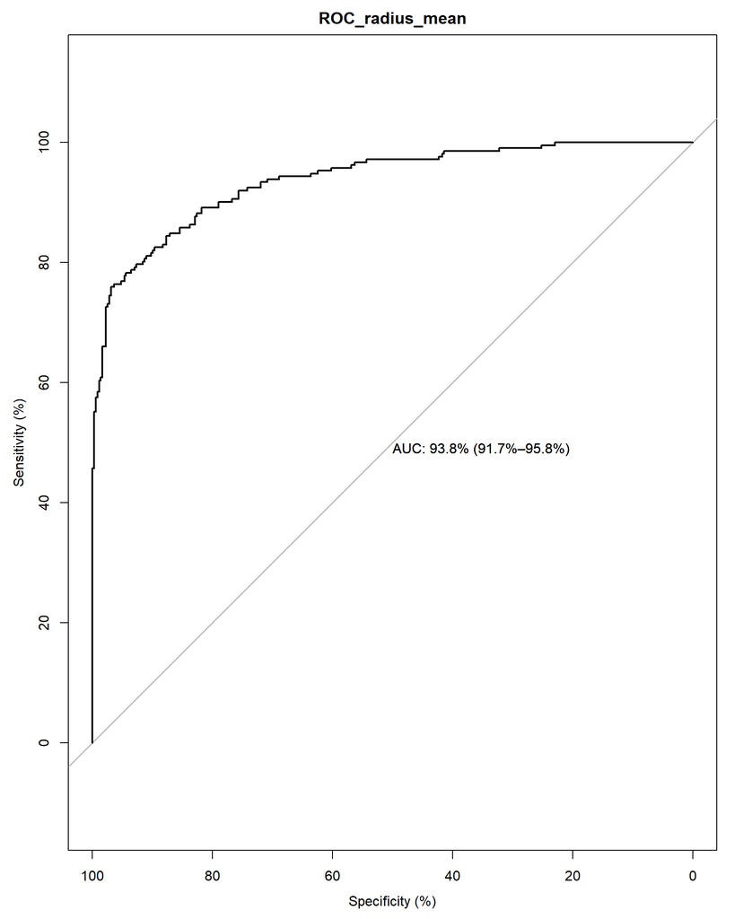

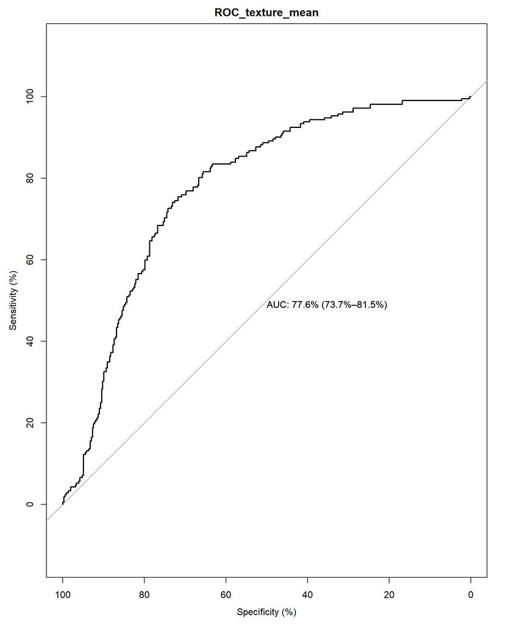

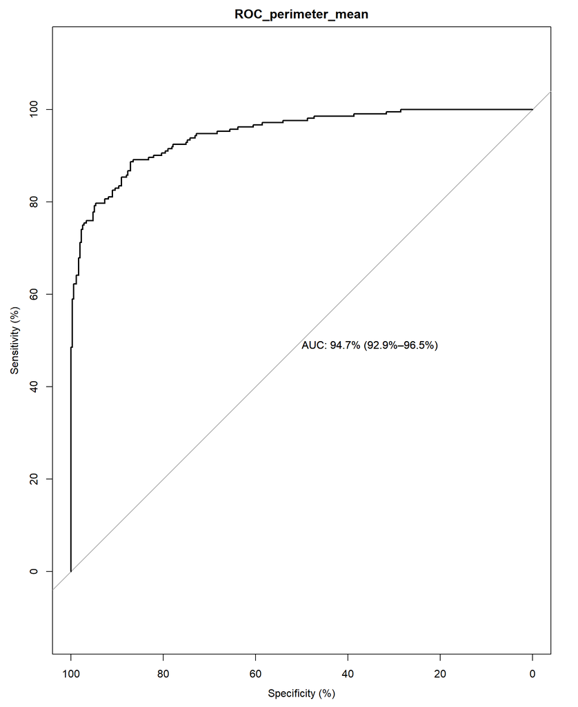

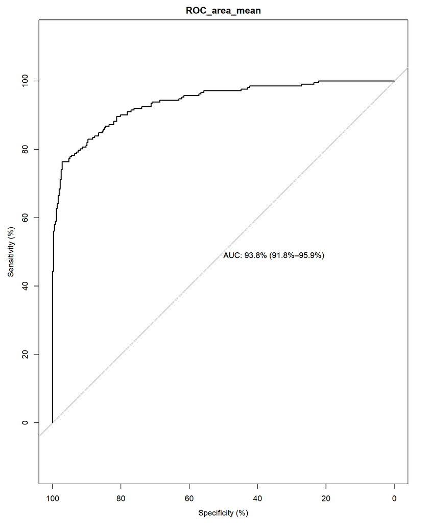

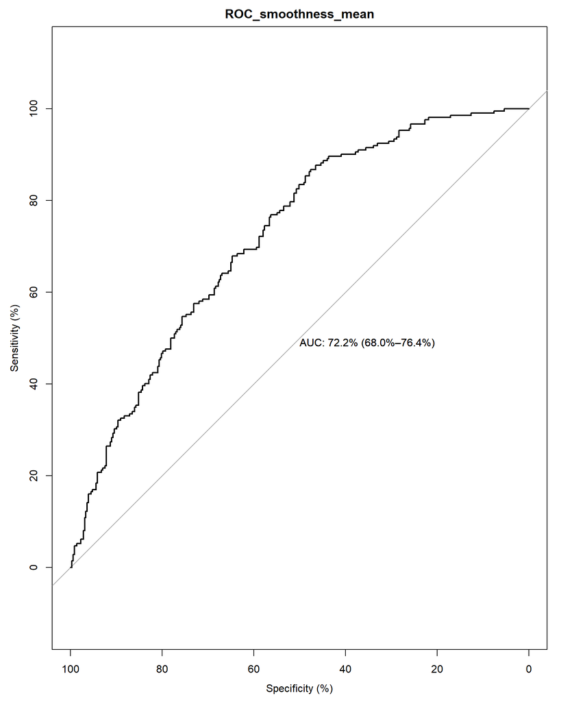

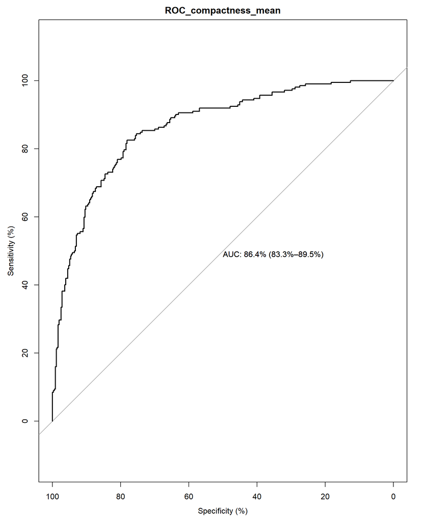

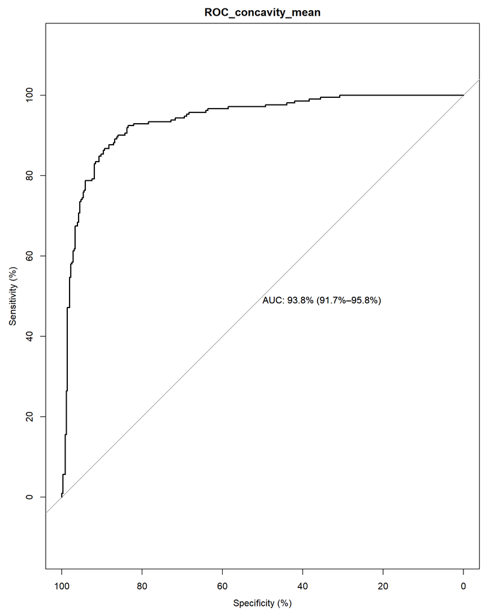

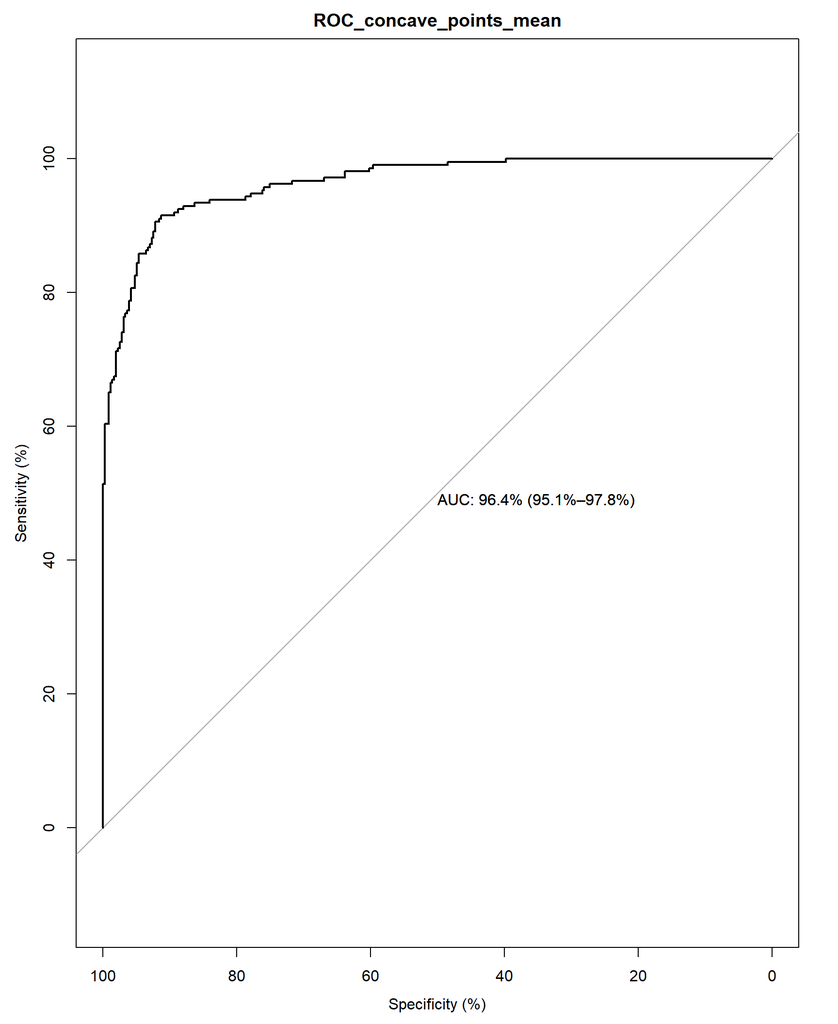

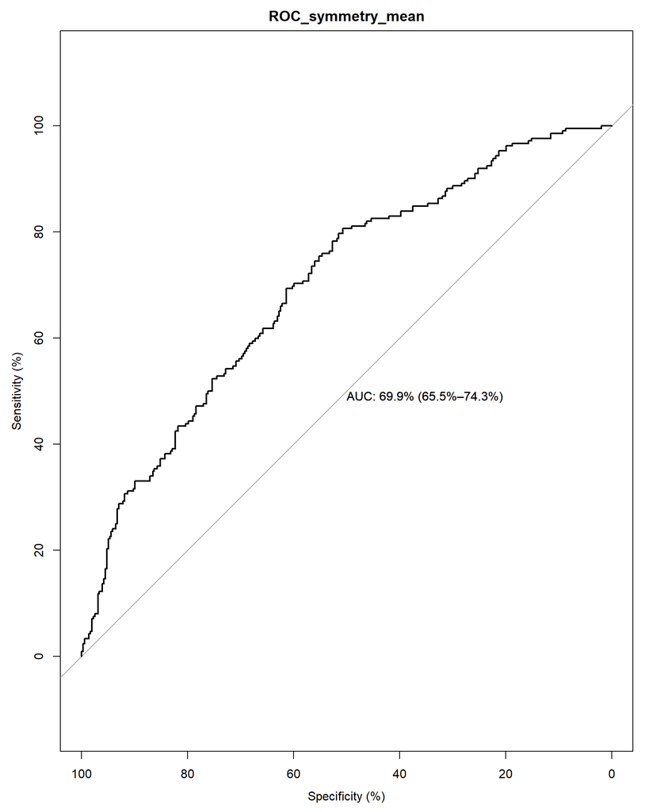

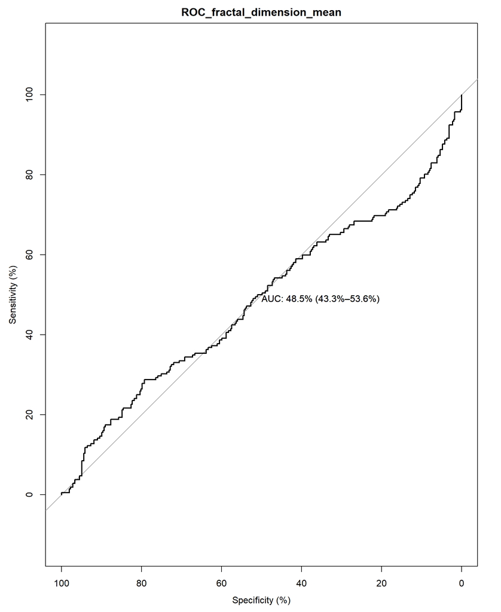

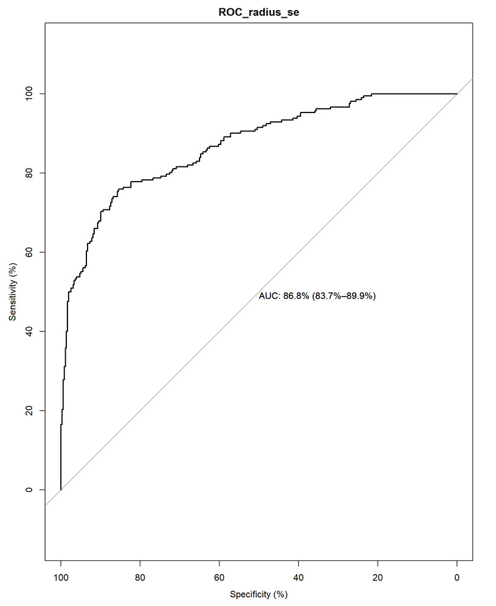

[19 more figures not shown]

Now all the curves in the same graph

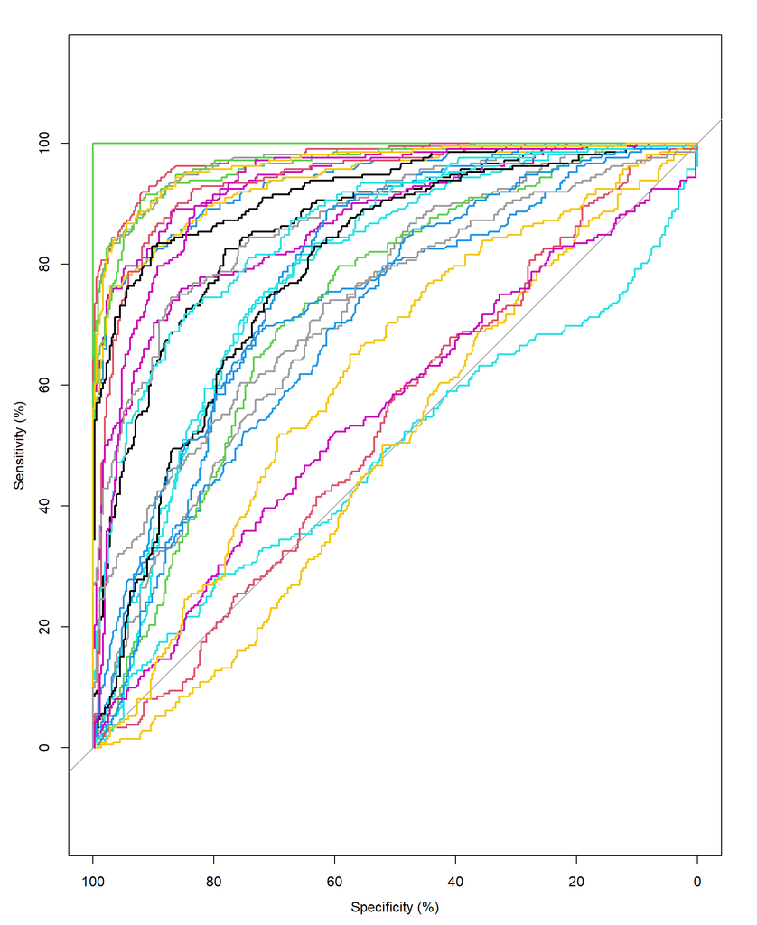

AUC indicator for each attribute (descending order)

| Attribute | AUC_(%) |
| --- | --- |
| perimeter_worst | 97.54506 |
| radius_worst | 97.04429 |
| area_worst | 96.98285 |
| concave_points_worst | 96.67037 |
| concave_points_mean | 96.44377 |
| perimeter_mean | 94.68976 |
| area_mean | 93.83159 |
| concavity_mean | 93.78270 |
| radius_mean | 93.75165 |
| area_se | 92.64111 |
| concavity_worst | 92.13638 |
| perimeter_se | 87.63940 |
| radius_se | 86.83341 |
| compactness_mean | 86.37823 |
| compactness_worst | 86.23025 |
| concave_points_se | 79.17922 |
| texture_worst | 78.46308 |
| concavity_se | 78.08189 |
| texture_mean | 77.58245 |
| smoothness_worst | 75.40563 |
| symmetry_worst | 73.69391 |
| compactness_se | 72.72805 |
| smoothness_mean | 72.20416 |
| symmetry_mean | 69.85624 |
| fractal_dimension_worst | 68.59706 |
| fractal_dimension_se | 62.03028 |
| symmetry_se | 55.51107 |
| smoothness_se | 53.11625 |
| texture_se | 48.84057 |
| fractal_dimension_mean | 48.45344 |

The features that show a higher AUC are more useful in predicting the labels since AUC is a measure of how well that single feature manages the trade-off between True Positives and False Positives.